# Similarity and Its Applications

Shaobo Li

```r
library(tidyverse)
```

## Similarity

There are different metrics to measure similarity between two objects. They are real-valued functions of a pair of vectors.

### Different similarity measures

#### Euclidean distance

One of the most commonly used measures is **Euclidean distance**. That is, given two vectors $X=(x_1, x_2, ..., x_p)$, $Y=(y_1, y_2, ..., y_p)$, the Euclidean distance between $X$ and $Y$ is
$$||X-Y||_2=\sqrt{(x_1-y_1)^2+(x_2-y_2)^2+...+(x_p-y_p)^2}$$
The notation $||\cdot||_2$ is also called $\ell_2$ norm. You will see this later when we learn ridge regression.

In R, it is very easy to compute this distance using function `dist()`. For example,

```r
x<- c(2, -2, 3, 5)
y<- c(1, 3, 0, 2)
z<- c(0, -1, 2, 2)
dist(rbind(x, y, z))
```

```
##          x        y
## y 6.633250
## z 3.872983 4.582576
```

Note that this is not a matrix object. It only shows the distance between all pairs. To get a matrix object, you need to convert it to matrix.

```r
as.matrix(dist(rbind(x, y, z)))
```

```
##          x        y        z
## x 0.000000 6.633250 3.872983
## y 6.633250 0.000000 4.582576
## z 3.872983 4.582576 0.000000
```

#### Manhattan distance

**Manhattan distance** is defined as
$$||X-Y||_1=|x_1-y_1|+|x_2-y_2|+...+|x_p-y_p|$$
The notation $||\cdot||_1$ is also called $\ell_1$ norm. You will see this later when we learn LASSO.

```r
as.matrix(dist(rbind(x, y, z), method = "manhattan"))
```

```
##    x  y z
## x  0 12 7
## y 12  0 7
## z  7  7 0
```

#### Cosine similarity

Cosine of the angle between two vectors. It is defined as
$$\cos(\theta)=\frac{X\cdot Y}{||X||_2\times
||Y||_2}$$

```r
library(proxy)
as.matrix(dist(rbind(x, y, z), method = "cosine"))
```

```
##           x         y         z
## x 0.0000000 0.7525642 0.0741799
## y 0.7525642 0.0000000 0.9109129
## z 0.0741799 0.9109129 0.0000000
```

#### Jaccard similarity

We can define a function by the definition of Jaccard similarity.

```r
jaccard <- function(a, b) {
    intersection = length(intersect(a, b))
    union = length(a) + length(b) - intersection
    return (intersection/union)
}
jaccard(x, y)
```

```
## [1] 0.3333333
```

#### Other similarity measures

There are many other similarity measures including correlation, Jaccard, binary… For different application, different measures are employed. For example, this [article](https://cmry.github.io/notes/euclidean-v-cosine) talks about Euclidean distance vs. Cosine similarity.

### Exercise

1. How to compute these similarity measures between two vectors without using `dist()`?
2. How to compute these similarity measures between three vectors without using `dist()`?
3. How to compute these similarity measures between n vectors without using `dist()`? Try to write a function just like `dist()`.

Back to top

## Recommendation systems (an example)

### Preprocess the data with text mining techniques.

Essentially, we need to split the column such as “genres” to multiple columns with each one indicating a single genre, and entries are 1 or 0, meaning the movie has or does not have this genre.

```r
movie<- read_csv("http://shaobo-li.github.io/Teaching/Data/movie.csv")
genre13<- movie$genres[c(1,3)]
genre13
```

```
## [1] "Action|Adventure|Fantasy|Sci-Fi" "Action|Adventure|Thriller"
```

```r
## use function gsub to split words
genre13_split <- gsub(genre13, pattern="\\|",replacement=" ")
genre13_split
```

```
## [1] "Action Adventure Fantasy Sci-Fi" "Action Adventure Thriller"
```

Next, use text mining technique to create a document matrix, which is something we described at the beginning.

```r
library(tm)
genre13.sparse.mat <- DocumentTermMatrix(Corpus(VectorSource(genre13_split)))
genre13.sparse.mat<- as.matrix(genre13.sparse.mat)
genre13.sparse.mat
```

```
##     Terms
## Docs action adventure fantasy sci-fi thriller
##    1      1         1       1      1        0
##    2      1         1       0      0        1
```

Then, we need to do this for all movies’ genres.

```r
genres<- (sapply(movie$genres,gsub,pattern="\\|",replacement=" "))
genre.sparse.mat <- DocumentTermMatrix(Corpus(VectorSource(genres)))
genre.sparse.mat<- as.matrix(genre.sparse.mat)
dim(genre.sparse.mat)
```

```
## [1] 5043   26
```

### Content-based filtering

Let’s get the recommended movies for a particular movie: “Dawn of the Planet of the Apes”.

First get the distance matrix.

```r
dist.mat<- as.matrix(dist(genre.sparse.mat))
dim(dist.mat)
```

```
## [1] 5043 5043
```

Then, figure out which row is “Dawn of the Planet of the Apes”.

```r
ind <- which(str_detect(movie$movie_title, "Dawn of the Planet of the Apes")==T)
```

Then, pull the distance vector. Remember, get rid of the distance to itself.

```r
dist_movie_Apes <- dist.mat[ind, -ind]
```

Finally, we can order the distances and get the first 10 movies.

```r
ind10 <- order(dist_movie_Apes)[1:10]
movie$movie_title[-ind][ind10]
```

```
##  [1] "The Postman "                        "Stargate SG-1 "
##  [3] "Space Battleship Yamato "            "Revolution "
##  [5] "John Carter "                        "Avengers: Age of Ultron "
##  [7] "Batman v Superman: Dawn of Justice " "Superman Returns "
##  [9] "The Avengers "                       "Captain America: Civil War "
```

Think about the meaning of the last line above?

#### Exercise:

Can you recommend top 5 movies that are similar to “Terminator 2: Judgment Day” in terms of Genres, duration and imdb score (using Euclidean distance)?

Back to top

## K-means clustering

We use the seeds data set to demonstrate clustering analysis in R. The examined group comprised kernels belonging to three different varieties of wheat: Kama, Rosa and Canadian, 70 elements each. A description of the dataset can be viewed at (https://archive.ics.uci.edu/ml/datasets/seeds)

```r
seed = read.table('http://archive.ics.uci.edu/ml/machine-learning-databases/00236/seeds_dataset.txt', header=F)
seed = seed[,1:7]
colnames(seed) = c("area", "perimeter","campactness", "length", "width", "asymmetry", "groovelength")
```

#### Scale data to have zero mean and unit variance for each column

This is important especially when different variables are in different scales. The reason is that the variables with large magnitude may dominate others when calculating the distance.

```r
seed <- scale(seed)
```

### Use k-means method for clustering and plot results.

```r
# K-Means Cluster Analysis
fit <- kmeans(seed, 5)
```

#### Plot cluster in kmeans

```r
install.packages("fpc")
```

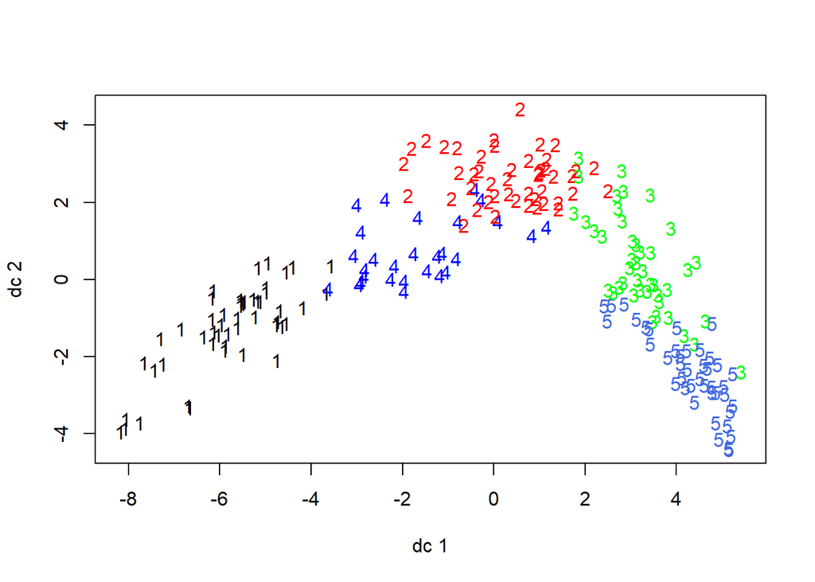

```r
library(fpc)
plotcluster(seed, fit$cluster)
```

We can get the number of observations in each cluster

```r
# Show the size of each cluster
fit$size
```

```
## [1] 50 47 43 28 42
```

```r
# equivalently
table(fit$cluster)
```

```
##
##  1  2  3  4  5
## 50 47 43 28 42
```

We can also get the center of each group

```r
fit$centers
```

```
##          area  perimeter campactness     length       width  asymmetry
## 1  1.45625907  1.4440841  0.65695353  1.4361072  1.33994144 -0.1504173
## 2 -0.08872467 -0.1235976  0.54409924 -0.2335320  0.07726067 -0.9467088
## 3 -0.81294678 -0.8745119 -0.02356008 -0.9356071 -0.67338952  0.2366382
## 4  0.47893181  0.5461231  0.14168175  0.5425752  0.44951443  0.1656874
## 5 -1.12133984 -1.0495847 -1.46129396 -0.8521514 -1.29188044  0.8857497
##   groovelength
## 1    1.4541952
## 2   -0.6145287
## 3   -0.8983806
## 4    0.5534299
## 5   -0.4926805
```

```r
# it is equivalent to using aggregate function
aggregate(seed, by=list(fit$cluster), FUN=mean)
```

```
##   Group.1        area  perimeter campactness     length       width  asymmetry
## 1       1  1.45625907  1.4440841  0.65695353  1.4361072  1.33994144 -0.1504173
## 2       2 -0.08872467 -0.1235976  0.54409924 -0.2335320  0.07726067 -0.9467088
## 3       3 -0.81294678 -0.8745119 -0.02356008 -0.9356071 -0.67338952  0.2366382
## 4       4  0.47893181  0.5461231  0.14168175  0.5425752  0.44951443  0.1656874
## 5       5 -1.12133984 -1.0495847 -1.46129396 -0.8521514 -1.29188044  0.8857497
##   groovelength
## 1    1.4541952
## 2   -0.6145287
## 3   -0.8983806
## 4    0.5534299
## 5   -0.4926805
```

We can extract all observations that are in 1st group

```r
seed[fit$cluster==1,]
```

#### Exercise:

How to get it using group_by() and summarise() you have learned.

#### Total, within-group, between group sum squared errors

```r
fit$totss
```

```
## [1] 1463
```

```r
fit$withinss
```

```
## [1] 85.09100 58.50475 90.00107 38.15899 55.21850
```

```r
fit$tot.withinss
```

```
## [1] 326.9743
```

```r
fit$betweenss
```

```
## [1] 1136.026
```

### Exercise

1. Can you tell the relationship between all these Sum Squared Errors.
2. Run above lines again (start from `kmeans()`), did you get the same result? Why?
3. ** Write your own k-means algorithm based on Euclidean distance by using function `dist()`.

### Determine number of clusters

Here a simple within group sum of squares (wss) method is used. We can calculate the wss for different number of clusters.

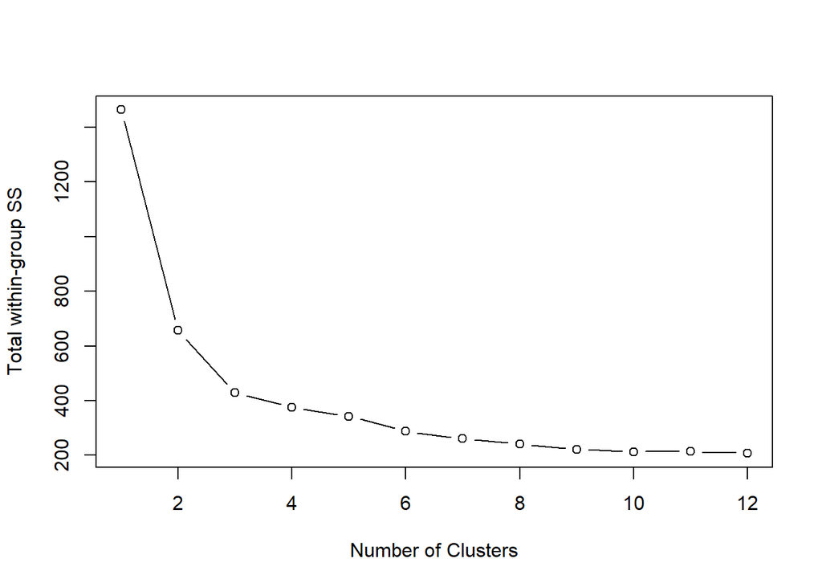

```r
wss <- rep(0, 12)
for (i in 1:12){
  wss[i] <- kmeans(seed, centers=i)$tot.withinss
}
plot(1:12, wss, type="b", xlab="Number of Clusters",ylab="Total within-group SS")
```

A general rule is called elbow rule. That is, choose the k such that the amount of decreasing from k to k+1 is much less than that from k-1 to k.

#### Further readings

The package `NbClust` provides 30 indexes for determining the optimal number of clusters in a data set.

For more sophiscated methods, see for example [blog](http://blog.echen.me/2011/03/19/counting-clusters/), or [course notes](http://www.bx.psu.edu/old/courses/bx-fall04/How_Many_Clusters.pdf).

[This article on Cross Validated](http://stats.stackexchange.com/a/133694/8622) provides a great illustration of the situations when k-means would fail.

Back to top

## K-nearest neighbor (KNN)

We demonstrate this simple machine learning algorithm using Iris dataset, a famous dataset for almost all machine learning courses.

### Load and prepare the data

```r
data("iris")
as_tibble(iris)
```

```
## # A tibble: 150 × 5
##    Sepal.Length Sepal.Width Petal.Length Petal.Width Species
##           <dbl>       <dbl>        <dbl>       <dbl> <fct>
##  1          5.1         3.5          1.4         0.2 setosa
##  2          4.9         3            1.4         0.2 setosa
##  3          4.7         3.2          1.3         0.2 setosa
##  4          4.6         3.1          1.5         0.2 setosa
##  5          5           3.6          1.4         0.2 setosa
##  6          5.4         3.9          1.7         0.4 setosa
##  7          4.6         3.4          1.4         0.3 setosa
##  8          5           3.4          1.5         0.2 setosa
##  9          4.4         2.9          1.4         0.2 setosa
## 10          4.9         3.1          1.5         0.1 setosa
## # … with 140 more rows
```

```r
# standardize values for features
iris[,1:4]<- scale(iris[,1:4])
```

Random split data to training (60%) and testing (40%)

```r
# random row indices
index<- sample(nrow(iris), 0.6*nrow(iris))
# split data to training and testing
iris.train<- iris[index,]
iris.test<- iris[-index,]
```

### Train the model

In R, `knn()` function is designed to perform K-nearest neighbor. It is in package `"class"`.

```r
install.packages("class")
```

```r
library(class)
knn.iris<- knn(train = iris.train[, -5], test = iris.test[, -5], cl=iris.train[,5], k=5)
knn.iris
```

```
##  [1] setosa     setosa     setosa     setosa     setosa     setosa
##  [7] setosa     setosa     setosa     setosa     setosa     setosa
## [13] setosa     setosa     setosa     setosa     setosa     setosa
## [19] setosa     setosa     setosa     versicolor versicolor versicolor
## [25] versicolor versicolor versicolor versicolor versicolor versicolor
## [31] versicolor versicolor versicolor versicolor versicolor versicolor
## [37] versicolor versicolor versicolor virginica  virginica  versicolor
## [43] virginica  virginica  virginica  virginica  virginica  virginica
## [49] virginica  virginica  virginica  virginica  versicolor virginica
## [55] virginica  virginica  virginica  virginica  virginica  virginica
## Levels: setosa versicolor virginica
```

Here, the function `knn()` requires at least 3 inputs (train, test, and cl), the rest inputs have defaut values. `train` is the training dataset without label (Y), and `test` is the testing sample without label. `cl` specifies the label of training dataset. By default $k=1$, which results in 1-nearest neighbor.

### Prediction accuracy

```r
table(iris.test[,5], knn.iris, dnn = c("True", "Predicted"))
```

```
##             Predicted
## True         setosa versicolor virginica
##   setosa         21          0         0
##   versicolor      0         18         0
##   virginica       0          2        19
```

```r
sum(iris.test[,5] != knn.iris)
```

```
## [1] 2
```

### Exercise

1. Try different k, see how the error rate changes.
2. ** Write your own KNN algorithm based on Euclidean distance by using function `dist()`.

Back to top